# Data Analysis using R

### Import necessary packages

I will first import all the necessary packages. As I’ll do data analysis, I’ll use R built in functions and also `ggplot` to plot certain graphs about the data to get better insights into it.

```r
install.packages('ggplot2')
library('ggplot2')
library('gridExtra')
library('lubridate')
```

### Import data

The next step is to import the data that we will work with. I’ve taken the dataset from [Kaggle](https://www.kaggle.com/joniarroba/noshowappointments/download) about **medical apppointments** with 13 features and a lable describing whether the person showed up for the appointment or not.

```r
medical.dataset <- read.csv('data/dataset.csv', header = TRUE, sep = ',')
head(medical.dataset)
```

|  | PatientId | AppointmentID | Gender | ScheduledDay | AppointmentDay | Age | Neighbourhood | Scholarship | Hipertension | Diabetes | Alcoholism | Handcap | SMS_received | No.show |
| --- | --- | --- | --- | --- | --- | --- | --- | --- | --- | --- | --- | --- | --- | --- |
| 1 | 2.987250e+13 | 5642903 | F | 2016-04-29T18:38:08Z | 2016-04-29T00:00:00Z | 62 | JARDIM DA PENHA | 0 | 1 | 0 | 0 | 0 | 0 | No |
| 2 | 5.589978e+14 | 5642503 | M | 2016-04-29T16:08:27Z | 2016-04-29T00:00:00Z | 56 | JARDIM DA PENHA | 0 | 0 | 0 | 0 | 0 | 0 | No |
| 3 | 4.262962e+12 | 5642549 | F | 2016-04-29T16:19:04Z | 2016-04-29T00:00:00Z | 62 | MATA DA PRAIA | 0 | 0 | 0 | 0 | 0 | 0 | No |
| 4 | 8.679512e+11 | 5642828 | F | 2016-04-29T17:29:31Z | 2016-04-29T00:00:00Z | 8 | PONTAL DE CAMBURI | 0 | 0 | 0 | 0 | 0 | 0 | No |
| 5 | 8.841186e+12 | 5642494 | F | 2016-04-29T16:07:23Z | 2016-04-29T00:00:00Z | 56 | JARDIM DA PENHA | 0 | 1 | 1 | 0 | 0 | 0 | No |
| 6 | 9.598513e+13 | 5626772 | F | 2016-04-27T08:36:51Z | 2016-04-29T00:00:00Z | 76 | REPÚBLICA | 0 | 1 | 0 | 0 | 0 | 0 | No |

The dataset is now loaded into the notebook. Let’s start exploring more information about the data.

### Exploratory data analysis

Let’s start the exploratory analysis of the dataset.

#### Dataset exploration

Let’s explore the information about the datset.

```r
print(paste("Rows: ", nrow(medical.dataset)))
```

```
[1] "Rows:  110527"
```

```r
print(paste("Columns: ", ncol(medical.dataset)))
```

```
[1] "Columns:  14"
```

The dataset has 110,527 rows and 14 columns out of which we know we have 13 features and 1 target.

```r
names(medical.dataset)
```

```
 [1] "PatientId"      "AppointmentID"  "Gender"         "ScheduledDay"   "AppointmentDay" "Age"            "Neighbourhood"  "Scholarship"    "Hipertension"   "Diabetes"       "Alcoholism"
[12] "Handcap"        "SMS_received"   "No.show"
```

I’ll start by renaming the target column as it’s a negation. I’ll also have to reverse the column values to accomodate this change.

```r
names(medical.dataset)[14] <- "Showed_up"
medical.dataset$Showed_up <- medical.dataset$Showed_up == 'No'
```

We have 13 features, let’s explore them furthermore:

1. “PatientId”: It is a unique identifier for each patient but would not be useful for any predictions.
2. "AppointmentId: It’s a unique identifier for each appointment.
3. “Gender”: Whether the person is a Female denoted by F or Male denoted by M.
4. “ScheduleDay”: The day on which appointment was scheduled.
5. “AppointmentDay”: The day of the appointment.
6. “Age”: Age of the person.
7. “Neighbourhood”: The neighbourhood to which the person belongs.
8. “Scholarship”: Whether the person had scholarship (defined [Wikipedia](https://en.wikipedia.org/wiki/Bolsa_Fam%C3%ADlia)).
9. “Hipertension”: Whether the person has hyptertension.
10. “Diabeletes”: Whether the person has diabetes.
11. “Alcoholism”: Whether the person is alcoholic.
12. “Handcap”: Whether the person is physically challenged.
13. “SMS_received”: Whether the person received a text message about the appointment.

The target variable is:

1. “Showed_up”: Depicts whether the person showed up for the appointment.

```r
summary(medical.dataset)
```

```
   PatientId         AppointmentID     Gender                  ScheduledDay                 AppointmentDay       Age                 Neighbourhood    Scholarship       Hipertension       Diabetes
 Min.   :3.922e+04   Min.   :5030230   F:71840   2016-05-06T07:09:54Z:    24   2016-06-06T00:00:00Z: 4692   Min.   : -1.00   JARDIM CAMBURI : 7717   Min.   :0.00000   Min.   :0.0000   Min.   :0.00000
 1st Qu.:4.173e+12   1st Qu.:5640286   M:38687   2016-05-06T07:09:53Z:    23   2016-05-16T00:00:00Z: 4613   1st Qu.: 18.00   MARIA ORTIZ    : 5805   1st Qu.:0.00000   1st Qu.:0.0000   1st Qu.:0.00000
 Median :3.173e+13   Median :5680573             2016-04-25T17:17:46Z:    22   2016-05-09T00:00:00Z: 4520   Median : 37.00   RESISTÊNCIA    : 4431   Median :0.00000   Median :0.0000   Median :0.00000
 Mean   :1.475e+14   Mean   :5675305             2016-04-25T17:18:27Z:    22   2016-05-30T00:00:00Z: 4514   Mean   : 37.09   JARDIM DA PENHA: 3877   Mean   :0.09827   Mean   :0.1972   Mean   :0.07186
 3rd Qu.:9.439e+13   3rd Qu.:5725524             2016-04-25T17:17:23Z:    19   2016-06-08T00:00:00Z: 4479   3rd Qu.: 55.00   ITARARÉ        : 3514   3rd Qu.:0.00000   3rd Qu.:0.0000   3rd Qu.:0.00000
 Max.   :1.000e+15   Max.   :5790484             2016-04-25T17:19:03Z:    15   2016-05-11T00:00:00Z: 4474   Max.   :115.00   CENTRO         : 3334   Max.   :1.00000   Max.   :1.0000   Max.   :1.00000
                                                 (Other)             :110402   (Other)             :83235                    (Other)        :81849
   Alcoholism        Handcap         SMS_received   Showed_up
 Min.   :0.0000   Min.   :0.00000   Min.   :0.000   Mode :logical
 1st Qu.:0.0000   1st Qu.:0.00000   1st Qu.:0.000   FALSE:22319
 Median :0.0000   Median :0.00000   Median :0.000   TRUE :88208
 Mean   :0.0304   Mean   :0.02225   Mean   :0.321
 3rd Qu.:0.0000   3rd Qu.:0.00000   3rd Qu.:1.000
 Max.   :1.0000   Max.   :4.00000   Max.   :1.000
```

The `summary` fuinction gives a really descriptive summary of what the dataset includes but I find using plots more useful and more understandable to get the essence of the dataset. Furthermore, the columns like Scholarship, Hipertension etc. are being considered as continuous values whereas they are just unqiue factors.

But we can begin by working with the information we get above. The minimum value of `Age` is actually `-1` which seems to be erroneous. I’ll remove the records that have these values.

```r
medical.dataset$ScheduledDay <- as.Date(medical.dataset$ScheduledDay)
medical.dataset$AppointmentDay <- as.Date(medical.dataset$AppointmentDay)
medical.dataset$Scholarship <-as.logical(medical.dataset$Scholarship)
medical.dataset$Hipertension <-as.logical(medical.dataset$Hipertension)
medical.dataset$Diabetes <-as.logical(medical.dataset$Diabetes)
medical.dataset$Alcoholism <-as.logical(medical.dataset$Alcoholism)
medical.dataset$Handcap <-as.logical(medical.dataset$Handcap)
medical.dataset$SMS_received <-as.logical(medical.dataset$SMS_received)
medical.dataset <- medical.dataset[medical.dataset$Age > 0, ]
summary(medical.dataset)
```

```
   PatientId         AppointmentID     Gender     ScheduledDay        AppointmentDay            Age                 Neighbourhood   Scholarship     Hipertension     Diabetes       Alcoholism
 Min.   :3.922e+04   Min.   :5030230   F:70118   Min.   :2015-11-10   Min.   :2016-04-29   Min.   :  1.00   JARDIM CAMBURI : 7586   Mode :logical   Mode :logical   Mode :logical   Mode :logical
 1st Qu.:4.174e+12   1st Qu.:5640490   M:36869   1st Qu.:2016-04-29   1st Qu.:2016-05-09   1st Qu.: 19.00   MARIA ORTIZ    : 5563   FALSE:96178     FALSE:85186     FALSE:99044     FALSE:103627
 Median :3.172e+13   Median :5680744             Median :2016-05-10   Median :2016-05-18   Median : 38.00   RESISTÊNCIA    : 4235   TRUE :10809     TRUE :21801     TRUE :7943      TRUE :3360
 Mean   :1.473e+14   Mean   :5675434             Mean   :2016-05-08   Mean   :2016-05-19   Mean   : 38.32   JARDIM DA PENHA: 3851
 3rd Qu.:9.434e+13   3rd Qu.:5725634             3rd Qu.:2016-05-20   3rd Qu.:2016-05-31   3rd Qu.: 56.00   ITARARÉ        : 3412
 Max.   :1.000e+15   Max.   :5790484             Max.   :2016-06-08   Max.   :2016-06-08   Max.   :115.00   CENTRO         : 3282
                                                                                                            (Other)        :79058
  Handcap        SMS_received    Showed_up
 Mode :logical   Mode :logical   Mode :logical
 FALSE:104747    FALSE:72402     FALSE:21680
 TRUE :2240      TRUE :34585     TRUE :85307
```

#### Visualizations

Let’s start by visualizing the data. I’ll begin by visualizing the target distribution.

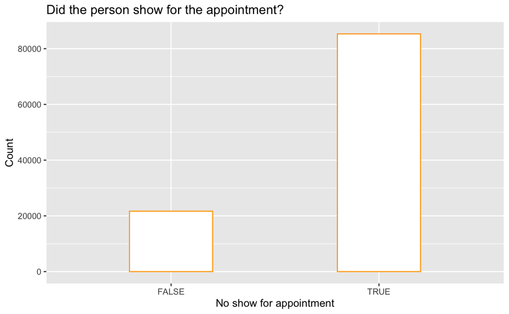

```r
ggplot(medical.dataset, aes(Showed_up)) +
  geom_bar(fill = 'white', color = 'orange', width = 0.4) +
  ggtitle("Did the person show for the appointment?") +
  labs(y="Count", x = "No show for appointment")
```

The dataset is highly skewed towards patients that showed up.

Let’s see the distribution between males and females.

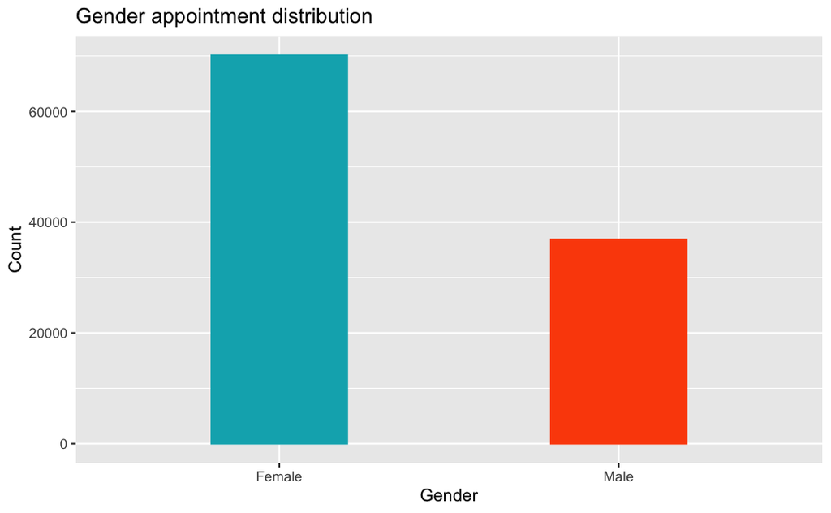

```r
ggplot(medical.dataset, aes(Gender)) +
  geom_bar(fill = c('#00AFBB', '#FC4E07'), color = c('#00AFBB', '#FC4E07'), width = 0.4) +
  ggtitle("Gender appointment distribution") +
  labs(y="Count", x = "Gender") +
  scale_x_discrete(labels=c("M" = "Male", "F" = "Female"))
```

This data is also skewed with more females as compared to males.

Let’s explore the other binary columns.

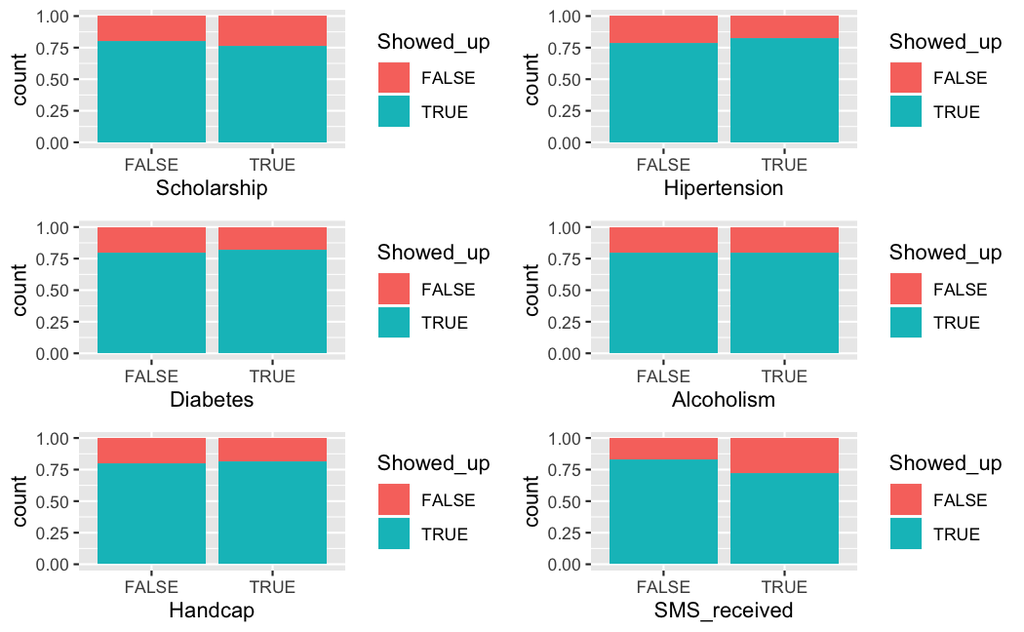

```r
grid.arrange(ggplot(medical.dataset, aes(x=Scholarship, fill=Showed_up)) + geom_bar(position="fill"),
             ggplot(medical.dataset, aes(x=Hipertension, fill=Showed_up)) + geom_bar(position="fill"),
             ggplot(medical.dataset, aes(x=Diabetes, fill=Showed_up)) + geom_bar(position="fill"),
             ggplot(medical.dataset, aes(x=Alcoholism, fill=Showed_up)) + geom_bar(position="fill"),
             ggplot(medical.dataset, aes(x=Handcap, fill=Showed_up)) + geom_bar(position="fill"),
             ggplot(medical.dataset, aes(x=SMS_received, fill=Showed_up)) + geom_bar(position="fill"), ncol = 2)
```

Let’s see how early to people set up their appointments.

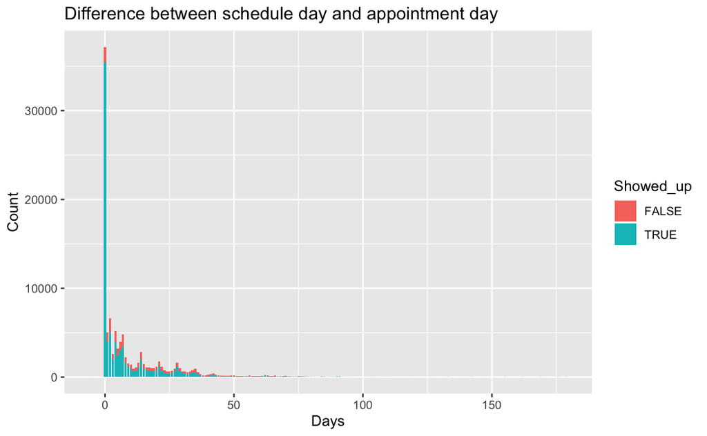

```r
date.diff <- as.data.frame(medical.dataset$AppointmentDay - medical.dataset$ScheduledDay)
names(date.diff) <- 'Days.difference'
medical.dataset$Date.diff <- as.numeric(unlist(date.diff))
ggplot(medical.dataset, aes(x = Date.diff, fill = Showed_up)) + geom_bar() +
  ggtitle("Difference between schedule day and appointment day") +
  labs(y="Count", x = "Days")
```

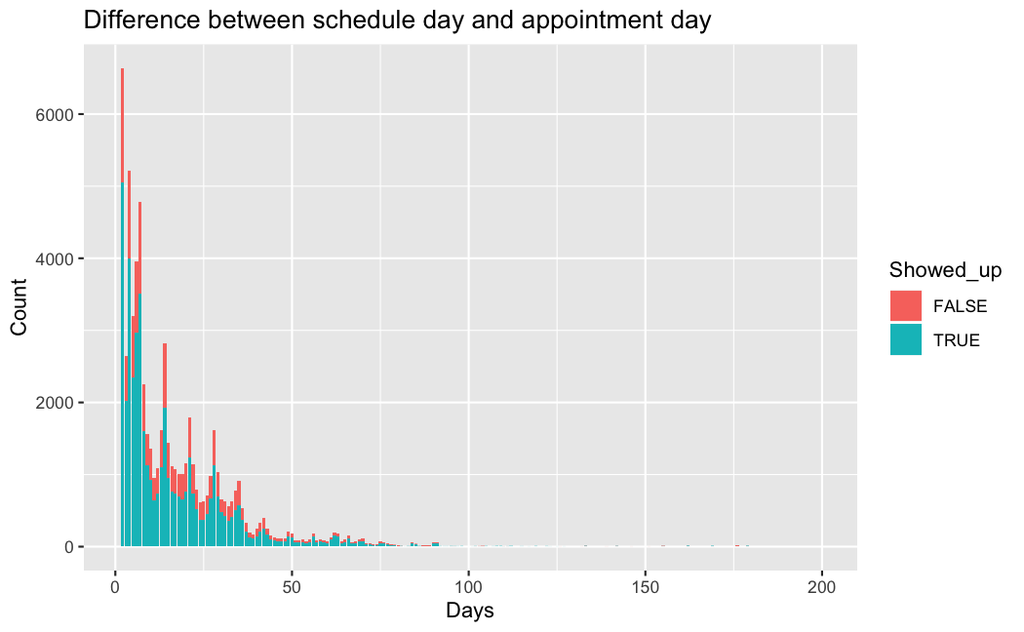

```r
ggplot(medical.dataset, aes(x = Date.diff, fill = Showed_up)) + geom_bar() +
  ggtitle("Difference between schedule day and appointment day") +
  labs(y="Count", x = "Days") + xlim(1,200)
```

The time of the hour or the month of the appointment might also affect if someone shows up for an appointment or not. So, let’s create that data and see if there is such as effect. I just noticed that the hour information of each appointment is the same so we can’t use that.

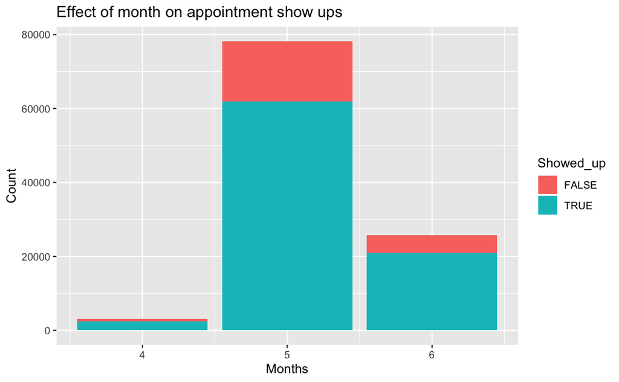

```r
medical.dataset$Month <- month(medical.dataset$AppointmentDay)
ggplot(medical.dataset, aes(x = Month, fill = Showed_up)) + geom_bar() +
  ggtitle("Effect of month on appointment show ups") +
  labs(y="Count", x = "Months")
```

There are very few appointments in April while May has the maximum number of appointments.

```r
prop.table(table(medical.dataset$Month, medical.dataset$Showed_up), margin = 1)
```

```
        FALSE      TRUE
  4 0.1958763 0.8041237
  5 0.2084218 0.7915782
  6 0.1858572 0.8141428
```

As we can see from the data, the month has almost no effect on show ups as the false and true ratio is almost the same. We can thus drop the column itself.

```r
medical.dataset <- subset(medical.dataset, select = -Month)
```

```r
unique(medical.dataset$Neighbourhood)
```

```
 [1] JARDIM DA PENHA             MATA DA PRAIA               PONTAL DE CAMBURI           REPÚBLICA                   GOIABEIRAS                  ANDORINHAS                  CONQUISTA
 [8] NOVA PALESTINA              DA PENHA                    TABUAZEIRO                  BENTO FERREIRA              SÃO PEDRO                   SANTA MARTHA                SÃO CRISTÓVÃO
[15] MARUÍPE                     GRANDE VITÓRIA              SANTO ANDRÉ                 SOLON BORGES                BONFIM                      JARDIM CAMBURI              MARIA ORTIZ
[22] JABOUR                      ANTÔNIO HONÓRIO             RESISTÊNCIA                 ILHA DE SANTA MARIA         JUCUTUQUARA                 MÁRIO CYPRESTE              SANTO ANTÔNIO
[29] BELA VISTA                  PRAIA DO SUÁ                SANTA HELENA                ITARARÉ                     INHANGUETÁ                  UNIVERSITÁRIO               SÃO JOSÉ
[36] REDENÇÃO                    SANTA CLARA                 CENTRO                      PARQUE MOSCOSO              DO MOSCOSO                  SANTOS DUMONT               CARATOÍRA
[43] ARIOVALDO FAVALESSA         ILHA DO FRADE               GURIGICA                    JOANA D´ARC                 CONSOLAÇÃO                  SÃO BENEDITO                PRAIA DO CANTO
[50] BOA VISTA                   SANTA LÚCIA                 BARRO VERMELHO              ESTRELINHA                  FORTE SÃO JOÃO              FONTE GRANDE                MORADA DE CAMBURI
[57] ENSEADA DO SUÁ              SANTOS REIS                 PIEDADE                     JESUS DE NAZARETH           SANTA LUÍZA                 SANTA TEREZA                CRUZAMENTO
[64] ILHA DO PRÍNCIPE            ROMÃO                       ILHA DAS CAIEIRAS           COMDUSA                     SANTA CECÍLIA               VILA RUBIM                  DE LOURDES
[71] MONTE BELO                  DO QUADRO                   DO CABRAL                   HORTO                       SEGURANÇA DO LAR            ILHA DO BOI                 FRADINHOS
[78] NAZARETH                    AEROPORTO                   ILHAS OCEÂNICAS DE TRINDADE PARQUE INDUSTRIAL
81 Levels: AEROPORTO ANDORINHAS ANTÔNIO HONÓRIO ARIOVALDO FAVALESSA BARRO VERMELHO BELA VISTA BENTO FERREIRA BOA VISTA BONFIM CARATOÍRA CENTRO COMDUSA CONQUISTA CONSOLAÇÃO CRUZAMENTO ... VILA RUBIM
```

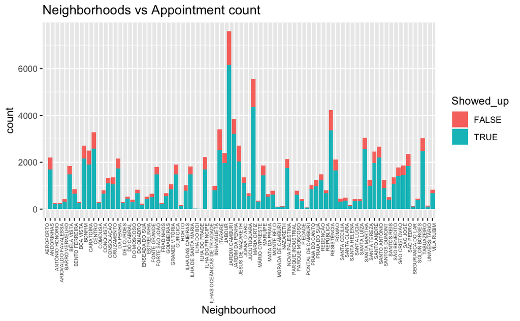

```r
ggplot(medical.dataset, aes(x = Neighbourhood, fill = Showed_up)) +
  geom_bar() +
  ggtitle("Neighborhoods vs Appointment count") +
  theme(axis.text.x = element_text(angle = 90, hjust = 1, size = 5))
```

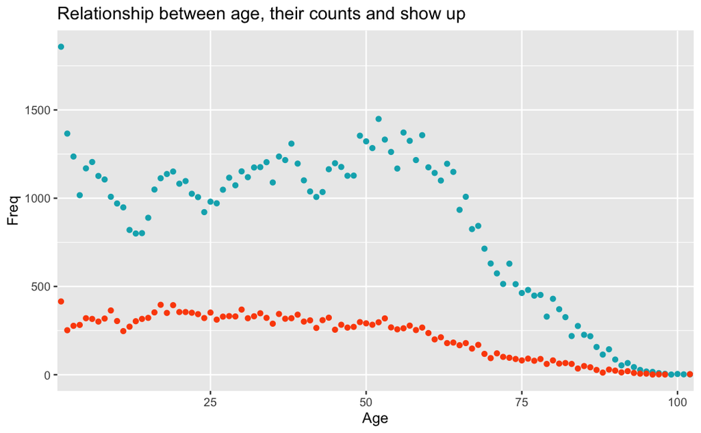

```r
age.show = as.data.frame(table(medical.dataset[medical.dataset$Showed_up == 'TRUE', ]$Age))
age.no_show = as.data.frame(table(medical.dataset[medical.dataset$Showed_up == 'FALSE', ]$Age))
ggplot(age.show, aes(x = Var1, y = Freq)) + geom_point(color = '#00AFBB') + geom_smooth(method = lm) +
  geom_point(data = age.no_show, aes(y = Freq), color = '#FC4E07') +
  scale_x_discrete(breaks = c(0, 25, 50, 75, 100, 125, 150), name = 'Age') +
  ggtitle("Relationship between age, their counts and show up")
```

The plot reveals that the number of appointments vary greatly by age. The maximum appointments are for infants. There is a drop and then a spike at around the age of 50. Finally, as the agre progresses less and less people set up appointments. Thus, age might have an effect on the target variable too.

Now, that we have a fairly good idea about the dataset. Let’s save it in its modified form and then use Python libraries to make prediction.

```r
write.csv(medical.dataset, file = 'data/dataset_modified.csv', row.names = FALSE)
```